# Assignment 2 - Part 2

Luca Carnegie

INF412

February 24, 2025

```python
# Install necessary packages
import pandas as pd
import seaborn as sns
import numpy as np
from matplotlib import pyplot as plt
from scipy import stats
import matplotlib.pyplot as plt

# import iris and reddit datasets
iris = pd.read_csv('iris.csv')
reddit = pd.read_csv('reddit.csv')
```

Q7) Develop descriptive statistics using the dataset “Reddit.csv” on Quercus. This dataset reflects some attributes of the conversation as well as the users in Reddit forum.

1. Create histograms for variables “Expertise” and “Days_in_reddit.” Please briefly discuss the shape being normally distributed or not. If it is skewed, describe the direction being left or right skewed.

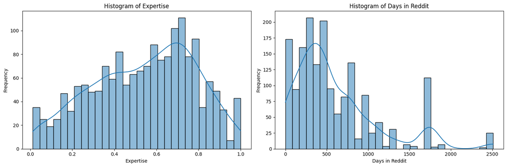

```python
# Create histograms for "Expertise" and "Days_in_reddit"
fig, axes = plt.subplots(1, 2, figsize=(15, 5))

sns.histplot(reddit['Expertise'], bins=30, kde=True, ax=axes[0])
axes[0].set_title('Histogram of Expertise')
axes[0].set_xlabel('Expertise')
axes[0].set_ylabel('Frequency')

sns.histplot(reddit['Days_in_reddit'], bins=30, kde=True, ax=axes[1])
axes[1].set_title('Histogram of Days in Reddit')
axes[1].set_xlabel('Days in Reddit')
axes[1].set_ylabel('Frequency')

plt.tight_layout()
plt.show()
```

2. Create boxplot for variable “WordCount.” And obtain the summary for Q1, Q3, max, min, median, and IQR.

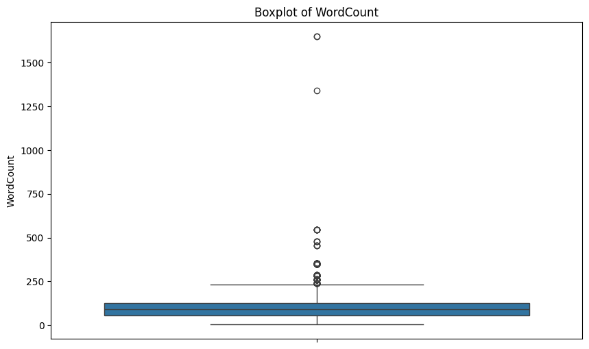

|  | Statistic | Value |
| --- | --- | --- |
| 0 | Q1 | 57.0 |
| 1 | Q3 | 127.0 |
| 2 | Max | 1650.0 |
| 3 | Min | 4.0 |
| 4 | Median | 91.0 |
| 5 | IQR | 70.0 |

```python
# Create vertical boxplot for "WordCount"
plt.figure(figsize=(10, 6))
sns.boxplot(y=reddit['WordCount'])
plt.title('Boxplot of WordCount')
plt.ylabel('WordCount')
plt.show()

# Present the summary in a table
summary_table = pd.DataFrame({
    'Statistic': ['Q1', 'Q3', 'Max', 'Min', 'Median', 'IQR'],
    'Value': [Q1, Q3, max_value, min_value, median, IQR]
})

summary_table
```

3. Please develop a table to show the mean, standard deviation and correlations between each variable in the “Reddit.csv” file.

```python
# Create a formatted table combining mean, std dev, and correlations
result = pd.DataFrame(index=desc_stats.index)

# Add mean and std dev
result['Mean'] = desc_stats['Mean'].round(3)
result['SD'] = desc_stats['Std Dev'].round(3)

# Create corellation matrix with entries above the diagonal dark grey
corr_matrix = reddit.corr()
mask = np.triu(np.ones_like(corr_matrix, dtype=bool))
cmap = sns.diverging_palette(230, 20, as_cmap=True)

# Add correlations
for col in corr_matrix.columns:
    result[f'{col}'] = corr_matrix[col].round(3)

# Display the result
result
```

|  | Mean | SD | Upvotes | Empathy | Suffer | Expertise | WordCount | Q_Breadth | Days_in_reddit | Membership | PostKarma | CommentKarma | Politeness | ReadScore |
| --- | --- | --- | --- | --- | --- | --- | --- | --- | --- | --- | --- | --- | --- | --- |
| Upvotes | 2.552 | 4.904 | 1.000 | 0.028 | -0.017 | -0.054 | -0.078 | 0.003 | 0.072 | -0.024 | -0.046 | -0.012 | 0.129 | -0.031 |
| Empathy | 0.295 | 0.051 | 0.028 | 1.000 | -0.107 | 0.037 | 0.027 | 0.019 | -0.007 | 0.013 | -0.054 | -0.019 | -0.010 | -0.049 |
| Suffer | 0.247 | 0.562 | -0.017 | -0.107 | 1.000 | 0.003 | 0.044 | 0.038 | -0.010 | 0.013 | 0.178 | 0.152 | -0.022 | 0.092 |
| Expertise | 0.542 | 0.241 | -0.054 | 0.037 | 0.003 | 1.000 | 0.072 | 0.136 | -0.205 | -0.283 | -0.066 | -0.046 | -0.073 | -0.069 |
| WordCount | 111.036 | 102.565 | -0.078 | 0.027 | 0.044 | 0.072 | 1.000 | -0.319 | -0.138 | 0.058 | 0.002 | -0.021 | -0.501 | 0.093 |
| Q_Breadth | -1.406 | 0.469 | 0.003 | 0.019 | 0.038 | 0.136 | -0.319 | 1.000 | -0.132 | 0.018 | 0.008 | -0.057 | 0.081 | -0.130 |
| Days_in_reddit | 600.590 | 515.745 | 0.072 | -0.007 | -0.010 | -0.205 | -0.138 | -0.132 | 1.000 | 0.007 | 0.295 | 0.258 | 0.115 | 0.180 |
| Membership | 0.007 | 0.007 | -0.024 | 0.013 | 0.013 | -0.283 | 0.058 | 0.018 | 0.007 | 1.000 | 0.013 | -0.019 | -0.085 | -0.013 |
| PostKarma | 3649.111 | 9721.210 | -0.046 | -0.054 | 0.178 | -0.066 | 0.002 | 0.008 | 0.295 | 0.013 | 1.000 | 0.676 | -0.062 | 0.018 |
| CommentKarma | 7237.546 | 17788.466 | -0.012 | -0.019 | 0.152 | -0.046 | -0.021 | -0.057 | 0.258 | -0.019 | 0.676 | 1.000 | 0.049 | 0.036 |
| Politeness | 0.374 | 0.162 | 0.129 | -0.010 | -0.022 | -0.073 | -0.501 | 0.081 | 0.115 | -0.085 | -0.062 | 0.049 | 1.000 | -0.053 |
| ReadScore | 63.447 | 32.538 | -0.031 | -0.049 | 0.092 | -0.069 | 0.093 | -0.130 | 0.180 | -0.013 | 0.018 | 0.036 | -0.053 | 1.000 |

**Q8) Using the iris.csv dataset posted on Quercus, perform the following statistical tests. The “iris” dataset includes the measurement (cm) of length and width of sepal and petal for three species.**

1. **One-Sample t-Test**
- Write the null and alternative hypothesis
- Choose the variable sepal_length and test if its mean is significantly different from a given population mean (5.8 cm)
- Report the p-value and interpret whether the mean significantly differs from the assumed value (alpha = 0.05)
- Check if this variable has nearly normal distribution by creating a histogram.

  **Null hypothesis (H₀):** μ = 5.8 cm (The mean sepal length equals 5.8 cm)

  **Alternative hypothesis (H₁):** μ ≠ 5.8 cm (The mean sepal length differs from 5.8 cm)

```python
# Perform one-sample t-test for sepal_length against population mean of 5.8
t_stat, p_value = stats.ttest_1samp(iris['sepal_length '], 5.8)

# Calculate sample mean
sample_mean = iris['sepal_length '].mean()

# Display the results in a dataframe
t_test_results = pd.DataFrame({
    'Sample Mean': [sample_mean],
    'Population Mean': [5.8],
    't-statistic': [t_stat],
    'p-value': [p_value]
}, index=['Sepal Length'])

t_test_results
```

|  | Sample Mean | Population Mean | t-statistic | p-value |
| --- | --- | --- | --- | --- |
| Sepal Length | 5.843333 | 5.8 | 0.640918 | 0.52256 |

**Conclusion**: The p value is greater than the alpha = 0.05, so we fail to reject the null hypothesis and say that there is no significant difference between the sample mean of sepal length and the given population mean of sepal length.

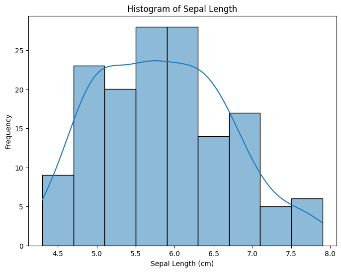

```python
# Check if sepal length has a nearly normal distribution by creating a histogram
plt.figure(figsize=(8, 6))
sns.histplot(iris['sepal_length '], kde=True)
plt.title('Histogram of Sepal Length')
plt.xlabel('Sepal Length (cm)')
plt.ylabel('Frequency')
plt.show()
```

We can see that the sepal length across Irises is somewhat normally distributed.

2. **Two-Sample t-Test**
- Write the null and alternative hypothesis
- Compare the mean sepal_width between two species (Virginica vs. Versicolor).
- Report the p-value and discuss whether the difference is statistically significant (alpha = 0.05)
- Check if these two groups have nearly normal distribution by creating histograms

```python
# Perform two-sample t-test
t_stat, p_value = stats.ttest_ind(virginica['sepal_width'], versicolor['sepal_width'], equal_var=True)

# Create a table with the results
result_df = pd.DataFrame({
    'Species': ['Virginica', 'Versicolor'],
    'Mean': [round(virginica['sepal_width'].mean(), 3), round(versicolor['sepal_width'].mean(), 3)],
    'Std Dev': [round(virginica['sepal_width'].std(), 3), round(versicolor['sepal_width'].std(), 3)]
})

# Add t-test results
t_test_df = pd.DataFrame({
    'Statistic': ['t-statistic', 'p-value'],
    'Value': [t_stat, p_value]
})

print("Group Statistics:")
display(result_df)
print("\nT-Test Results:")
display(t_test_df)
```

```
Group Statistics:
```

|  | Species | Mean | Std Dev |
| --- | --- | --- | --- |
| 0 | Virginica | 2.974 | 0.322 |
| 1 | Versicolor | 2.770 | 0.314 |

```
T-Test Results:
```

|  | Statistic | Value |
| --- | --- | --- |
| 0 | t-statistic | 3.205761 |
| 1 | p-value | 0.001819 |

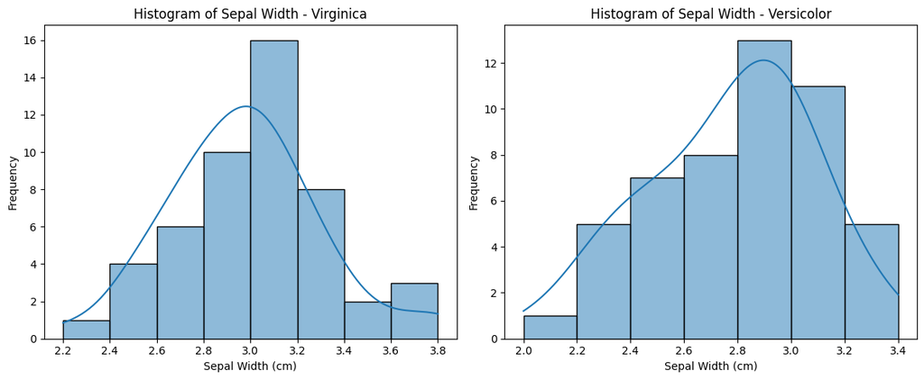

```python
# Separate data for the two species
virginica = iris[iris['species'] == 'virginica']
versicolor = iris[iris['species'] == 'versicolor']

# Create histograms to check normality of distributions
fig, ax = plt.subplots(1, 2, figsize=(12, 5))

sns.histplot(virginica['sepal_width'], kde=True, ax=ax[0])
ax[0].set_title('Histogram of Sepal Width - Virginica')
ax[0].set_xlabel('Sepal Width (cm)')
ax[0].set_ylabel('Frequency')

sns.histplot(versicolor['sepal_width'], kde=True, ax=ax[1])
ax[1].set_title('Histogram of Sepal Width - Versicolor')
ax[1].set_xlabel('Sepal Width (cm)')
ax[1].set_ylabel('Frequency')

plt.tight_layout()
plt.show()
```

We can see from the plots that both species are more or less normally distributed.

3. **ANOVA**
- Write the null and alternative hypothesis
- Compare the mean sepal_length across the three species (Setosa, Versicolor, and Virginica)
- Report the F-statistic and p-value, and interpret whether the difference is statistically significant (alpha = 0.05)
- Check if these three groups have nearly normal distribution by creating histograms

  **Null Hypothesis (H₀):** μ_Setosa = μ_Versicolor = μ_Virginica (The mean sepal length is equal across all three species: Setosa, Versicolor, and Virginica)

  **Alternative Hypothesis (H₁):** At least one species mean differs from the others (The mean sepal length differs for at least one of the three species)

```python
# Separate data for the three species
virginica = iris[iris['species'] == 'virginica']
versicolor = iris[iris['species'] == 'versicolor']
setosa = iris[iris['species'] == 'setosa']

#  Perform ANOVA test to compare means across three species
f_value, p_value = stats.f_oneway(
    setosa['sepal_length '],
    versicolor['sepal_length '],
    virginica['sepal_length ']
)

# Create table of summary statistics
summary_table = pd.DataFrame({
    'Species': ['Setosa', 'Versicolor', 'Virginica'],
    'Mean': [round(setosa['sepal_length '].mean(), 3),
             round(versicolor['sepal_length '].mean(), 3),
             round(virginica['sepal_length '].mean(), 3)],
    'Std Dev': [round(setosa['sepal_length '].std(), 3),
                round(versicolor['sepal_length '].std(), 3),
                round(virginica['sepal_length '].std(), 3)]
})

# Create a table for the ANOVA results
anova_results = pd.DataFrame({
    'Statistic': ['F-value', 'p-value'],
    'Value': [f_value, p_value]
})

# Display the tables
print("Group Statistics:")
display(summary_table)

print("ANOVA Results:")
display(anova_results)
```

```
Group Statistics:
```

|  | Species | Mean | Std Dev |
| --- | --- | --- | --- |
| 0 | Setosa | 5.006 | 0.352 |
| 1 | Versicolor | 5.936 | 0.516 |
| 2 | Virginica | 6.588 | 0.636 |

```
ANOVA Results:
```

|  | Statistic | Value |
| --- | --- | --- |
| 0 | F-value | 1.192645e+02 |
| 1 | p-value | 1.669669e-31 |

**Conclusion:** We observe that our p-value is lower than our alpha = 0.05, so we reject the null hypothesis and say that the mean sepal length differs for at least one of the three species between the species that were analysed (setosa, versicolor, and virginica)

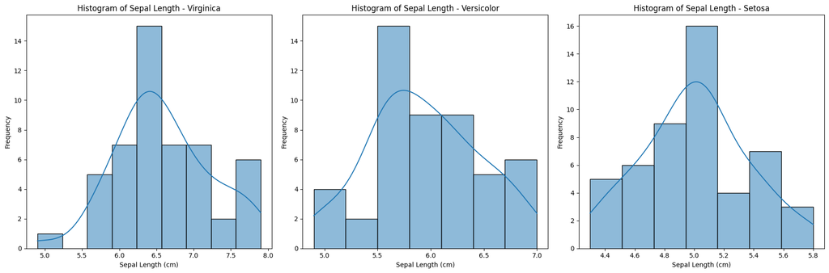

```python
# Create a new figure with 3 subplots
fig, axes = plt.subplots(1, 3, figsize=(18, 6))

sns.histplot(virginica['sepal_length '], kde=True, ax=axes[0])
axes[0].set_title('Histogram of Sepal Length - Virginica')
axes[0].set_xlabel('Sepal Length (cm)')
axes[0].set_ylabel('Frequency')

sns.histplot(versicolor['sepal_length '], kde=True, ax=axes[1])
axes[1].set_title('Histogram of Sepal Length - Versicolor')
axes[1].set_xlabel('Sepal Length (cm)')
axes[1].set_ylabel('Frequency')

sns.histplot(setosa['sepal_length '], kde=True, ax=axes[2])
axes[2].set_title('Histogram of Sepal Length - Setosa')
axes[2].set_xlabel('Sepal Length (cm)')
axes[2].set_ylabel('Frequency')

plt.tight_layout()
plt.show()
```

The three groups all look approximately normally distributed from their graphs.